# 04 · Marco Teórico y Visualizaciones Clave

Rotación Laboral Voluntaria — Fundamentos y Evidencia Empírica

Felipe Obregón Ochoa · Psicólogo

2026-06-05

# 1 Introducción

La rotación laboral voluntaria constituye uno de los fenómenos más estudiados en psicología organizacional, y su relevancia no ha disminuido con el tiempo. En contextos de alta demanda de talento especializado como la minería chilena, donde se proyecta una necesidad de más de 34.000 nuevos trabajadores entre 2023 y 2032 (Estudio de Fuerza Laboral de la Gran Minería Chilena, CCM-Eleva, 2023), comprender por qué las personas deciden abandonar sus organizaciones es una pregunta con consecuencias estratégicas directas.

Este notebook integra el marco teórico que fundamenta los patrones observados en el análisis exploratorio, junto con las visualizaciones más relevantes del dataset IBM HR Analytics. El objetivo es que el dato y la teoría conversen — no que coexistan en documentos separados.

# 2 Marco Teórico — Rotación Laboral Voluntaria en Contexto Organizacional

## 2.1 Los modelos clásicos y sus limitaciones

Los primeros modelos sistemáticos de rotación laboral adoptaron una lógica lineal: la insatisfacción laboral precedía la búsqueda de alternativas, y esta última antecedía la decisión de abandono (Mobley, 1977). Price y Mueller (1981) ampliaron este modelo incorporando variables estructurales como las oportunidades de promoción y los niveles salariales como antecedentes de la satisfacción.

Sin embargo, estas aproximaciones explicaban entre un 5% y un 25% de la varianza observada en rotación voluntaria (Mitchell et al., 2001), lo que evidenciaba que el fenómeno respondía a una complejidad mayor. Un empleado puede estar satisfecho con su trabajo y aun así irse. Otro puede estar insatisfecho y quedarse. La linealidad del modelo resultaba insuficiente.

## 2.2 El Modelo de Despliegue y las trayectorias de salida

Lee y Mitchell (1994) propusieron una reformulación radical del paradigma dominante. Su argumento central era que no existe una única trayectoria hacia la rotación, sino al menos cuatro vías diferenciadas según cómo cada persona procesa su decisión de salida.

La primera y segunda vías involucran un evento disruptivo — lo que los autores llamaron shock — que activa una evaluación, con o sin comparación deliberada de alternativas. La tercera vía, conceptualmente central para este análisis, ocurre cuando una promesa implícita o explícita no es cumplida por la organización, generando una ruptura del contrato psicológico que moviliza la búsqueda activa de salida. La cuarta vía, en cambio, no requiere evento detonante: el empleado se va por inercia o desalineación acumulada, sin haber realizado comparación con alternativas.

## 2.3 El efecto honeymoon-hangover

Boswell, Boudreau y Tichy (2005) modelaron la evolución de la satisfacción laboral en trabajadores que cambian de empleo, identificando tres fases secuenciales. La primera, de deterioración, corresponde a la caída de satisfacción en el empleo anterior que precede la decisión de cambio. La segunda, el honeymoon, es el período de alta satisfacción inmediatamente posterior al ingreso. La tercera, el hangover, es el decline gradual de vuelta a la línea base o por debajo de ella.

La profundidad de ese decline, según Boswell et al. (2009), depende significativamente del grado en que la realidad organizacional confirma o desmiente las expectativas iniciales. Cuando la brecha es amplia, el hangover es pronunciado y la probabilidad de salida aumenta de forma notable en los primeros veinticuatro meses.

Este mecanismo adquiere especial relevancia en el contexto minero chileno actual. Las nuevas generaciones, y en particular la Generación Z, ya no evalúan una oferta laboral exclusivamente por el salario: buscan propósito, crecimiento visible, equilibrio vida-trabajo y coherencia entre los valores declarados por la organización y su experiencia cotidiana (Diario Usach, 2026; Buk, 2025). No por casualidad la permanencia promedio de un joven de la Generación Z en su primer trabajo alcanza apenas 1,1 años (Randstad, citado en Buk, 2025).

## 2.4 El arraigo laboral como contrapeso de la salida

Frente a la pregunta de por qué las personas se van, Mitchell et al. (2001) propusieron la pregunta complementaria: por qué se quedan. Su respuesta fue el constructo de job embeddedness — arraigo laboral — definido como el conjunto de fuerzas que anclan al empleado en su posición actual, análogas a una red de conexiones que dificultan el movimiento.

El arraigo se articula en tres dimensiones interdependientes. La primera, fit o compatibilidad, refiere al grado en que el empleado percibe que sus valores, metas y planes de carrera son compatibles con la cultura organizacional y el entorno comunitario. La segunda, links o vínculos, comprende las conexiones formales e informales entre el empleado y otras personas o instituciones dentro y fuera de la organización. La tercera, sacrifice o sacrificio, captura el costo percibido de los recursos materiales y psicológicos que se perderían al abandonar el puesto.

Un metaanálisis con 65 muestras independientes y más de 42.000 participantes confirmó que el arraigo laboral predice la rotación voluntaria con mayor precisión que la satisfacción laboral, el compromiso organizacional y la disponibilidad de alternativas, considerados de forma aislada (Jiang et al., 2012). En el contexto minero de la II Región de Chile, la dimensión off-the-job del embeddedness — raíces familiares, redes comunitarias, arraigo territorial en Antofagasta — puede operar como factor de retención incluso cuando la satisfacción laboral es moderada (Mitchell et al., 2001).

## 2.5 La ruptura del contrato psicológico

Rousseau (1989) introdujo el concepto de contrato psicológico para referirse al conjunto de creencias individuales sobre las obligaciones mutuas implícitas en la relación laboral. Su incumplimiento — lo que Morrison y Robinson (1997) distinguen como breach, percepción cognitiva de incumplimiento, y violation, respuesta emocional intensa ante ese incumplimiento — tiene consecuencias documentadas sobre la confianza, el compromiso y la intención de permanecer.

## 2.6 El agotamiento emocional como mecanismo de salida

El análisis de la variable OverTime — que en el dataset triplica la probabilidad de rotación — requiere un marco explicativo adicional. Maslach y Leiter (1997) identificaron el agotamiento emocional como el componente central del burnout organizacional: la sensación de estar sobre-exigido y vaciado de recursos emocionales y físicos, sin capacidad de reposición.

Cuando la demanda de tiempo supera de forma sistemática los recursos disponibles del trabajador, la salida voluntaria emerge como la respuesta más accesible para recuperar el control sobre el propio bienestar. En el contexto de la minería chilena, donde los turnos prolongados y la lejanía del hogar son condiciones estructurales del trabajo en faena, este mecanismo no puede ignorarse en ningún modelo de retención (CCM-Eleva, 2023).

# 3 Visualizaciones clave — evidencia empírica del marco teórico

> **Nota metodológica:** Las visualizaciones a continuación muestran asociaciones estadísticas, no relaciones causales. Su interpretación se fundamenta en los marcos teóricos desarrollados en la sección anterior.

## 3.1 Perfil de rotación por antigüedad — el hangover en los datos

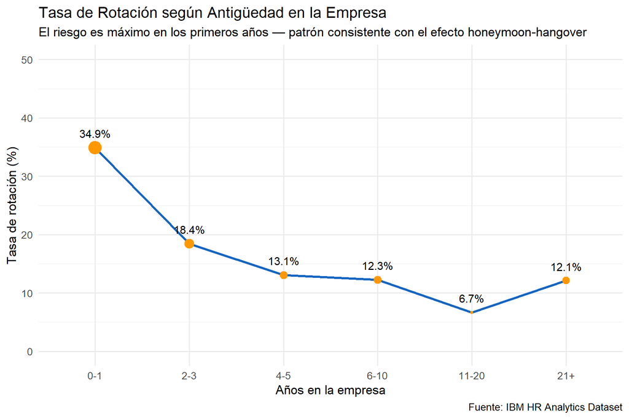

```r
plot_anios <- df %>%
  mutate(tramo_anios = cut(YearsAtCompany,
                           breaks = c(-Inf, 1, 3, 5, 10, 20, Inf),
                           labels = c("0-1", "2-3", "4-5", "6-10", "11-20", "21+"))) %>%
  count(tramo_anios, Attrition) %>%
  group_by(tramo_anios) %>%
  mutate(tasa = n / sum(n) * 100) %>%
  filter(Attrition == "Yes") %>%
  ggplot(aes(x = tramo_anios, y = tasa)) +
  geom_line(color = "#1565C0", linewidth = 1.2, group = 1) +
  geom_point(aes(size = tasa), color = "#FF9800", show.legend = FALSE) +
  geom_text(aes(label = paste0(round(tasa, 1), "%")),
            vjust = -1.2, size = 4) +
  scale_y_continuous(limits = c(0, 50)) +
  theme_minimal(base_size = 13) +
  labs(
    title    = "Tasa de Rotación según Antigüedad en la Empresa",
    subtitle = "El riesgo es máximo en los primeros años — patrón consistente con el efecto honeymoon-hangover",
    x        = "Años en la empresa",
    y        = "Tasa de rotación (%)",
    caption  = "Fuente: IBM HR Analytics Dataset"
  )

plot_anios
```

La curva de antigüedad muestra el patrón descrito por Boswell et al. (2005): una concentración de rotación en los primeros años que decrece progresivamente a medida que el arraigo organizacional se consolida. El leve repunte en el tramo de 21+ años merece cautela interpretativa dado el tamaño reducido de ese segmento, aunque podría reflejar un segundo momento de vulnerabilidad asociado a barreras de desarrollo tardío o cambios en las expectativas de carrera.

## 3.2 Horas extra y agotamiento — el predictor más potente

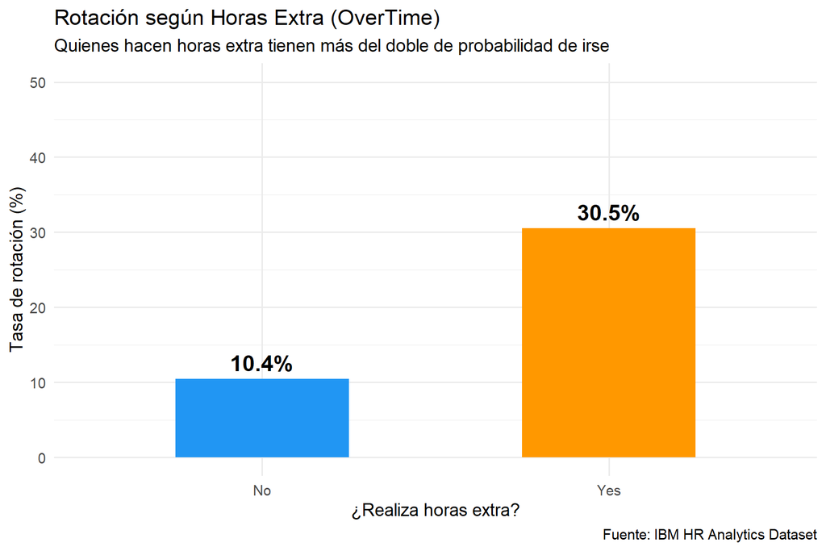

```r
plot_overtime <- df %>%
  count(OverTime, Attrition) %>%
  group_by(OverTime) %>%
  mutate(tasa = n / sum(n) * 100) %>%
  filter(Attrition == "Yes") %>%
  ggplot(aes(x = OverTime, y = tasa, fill = OverTime)) +
  geom_col(width = 0.5, show.legend = FALSE) +
  geom_text(aes(label = paste0(round(tasa, 1), "%")),
            vjust = -0.5, size = 6, fontface = "bold") +
  scale_fill_manual(values = c("No" = "#2196F3", "Yes" = "#FF9800")) +
  scale_y_continuous(limits = c(0, 50)) +
  theme_minimal(base_size = 14) +
  labs(
    title    = "Rotación según Horas Extra (OverTime)",
    subtitle = "Quienes hacen horas extra tienen más del doble de probabilidad de irse",
    x        = "¿Realiza horas extra?",
    y        = "Tasa de rotación (%)",
    caption  = "Fuente: IBM HR Analytics Dataset"
  )

plot_overtime
```

La diferencia entre 10.4% y 30.5% es el hallazgo de mayor consistencia en todo el análisis exploratorio. Es coherente con la literatura sobre agotamiento emocional (Maslach y Leiter, 1997): la sobrecarga sostenida vacía los recursos del trabajador hasta hacer de la salida la respuesta más razonable disponible.

## 3.3 Distribución del ingreso — equidad percibida y sacrificio

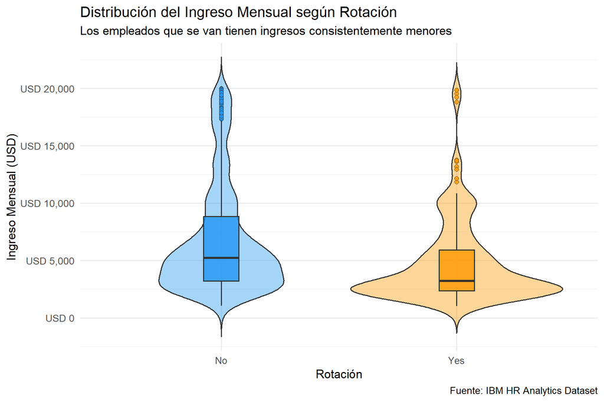

```r
plot_ingreso <- df %>%
  ggplot(aes(x = Attrition, y = MonthlyIncome, fill = Attrition)) +
  geom_violin(alpha = 0.4, trim = FALSE) +
  geom_boxplot(width = 0.15, alpha = 0.8,
               outlier.shape = 21, outlier.size = 2) +
  scale_fill_manual(values = c("No" = "#2196F3", "Yes" = "#FF9800")) +
  scale_y_continuous(labels = scales::dollar_format(prefix = "USD ")) +
  theme_minimal(base_size = 13) +
  theme(legend.position = "none") +
  labs(
    title    = "Distribución del Ingreso Mensual según Rotación",
    subtitle = "Los empleados que se van tienen ingresos consistentemente menores",
    x        = "Rotación",
    y        = "Ingreso Mensual (USD)",
    caption  = "Fuente: IBM HR Analytics Dataset"
  )

plot_ingreso
```

La distribución del ingreso no es homogénea dentro del grupo que se fue. Al observar la forma del violín en el grupo “Yes”, es posible identificar al menos dos concentraciones de densidad, lo que sugiere que no existe un único perfil salarial asociado a la salida voluntaria. Esta heterogeneidad es consistente con lo que la literatura describe como dos momentos críticos en la trayectoria laboral.

El primero ocurre en los años iniciales, cuando la satisfacción declina desde su punto más alto hacia un nivel de equilibrio inferior — fenómeno conocido como el efecto honeymoon-hangover (Boswell et al., 2005). Durante esta fase, la brecha entre las expectativas de ingreso y la compensación real puede actuar como detonante de la decisión de salida, especialmente cuando el empleado percibe que la organización no ha cumplido las promesas implícitas asociadas al proceso de incorporación (Rousseau, 1989).

El segundo momento aparece más avanzada la trayectoria, cuando empleados con mayor antigüedad enfrentan barreras de desarrollo que limitan su progresión salarial y profesional. Este patrón es coherente con la noción de ruptura del contrato psicológico en su dimensión de desarrollo de carrera (Morrison y Robinson, 1997).

## 3.4 Satisfacción laboral — el fit como ancla

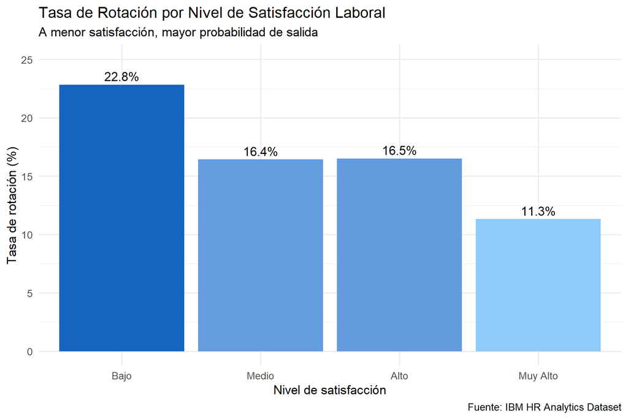

```r
plot_satisfaccion <- df %>%
  mutate(Attrition_num = ifelse(Attrition == "Yes", 1, 0)) %>%
  group_by(JobSatisfaction) %>%
  summarise(tasa = mean(Attrition_num) * 100) %>%
  ggplot(aes(x = factor(JobSatisfaction), y = tasa, fill = tasa)) +
  geom_col(show.legend = FALSE) +
  geom_text(aes(label = paste0(round(tasa, 1), "%")),
            vjust = -0.4, size = 4.5) +
  scale_fill_gradient(low = "#90CAF9", high = "#1565C0") +
  scale_y_continuous(limits = c(0, 25)) +
  scale_x_discrete(labels = c("1" = "Bajo", "2" = "Medio",
                               "3" = "Alto", "4" = "Muy Alto")) +
  theme_minimal(base_size = 13) +
  labs(
    title    = "Tasa de Rotación por Nivel de Satisfacción Laboral",
    subtitle = "A menor satisfacción, mayor probabilidad de salida",
    x        = "Nivel de satisfacción",
    y        = "Tasa de rotación (%)",
    caption  = "Fuente: IBM HR Analytics Dataset"
  )

plot_satisfaccion
```

La satisfacción laboral opera como indicador del fit organizacional — la compatibilidad percibida entre el empleado y su entorno de trabajo (Mitchell et al., 2001). El gradiente visible en el gráfico es consistente con el metaanálisis de Jiang et al. (2012): cuando el fit se deteriora, el arraigo disminuye y la probabilidad de salida aumenta. La intervención preventiva no debería esperar a que la satisfacción llegue a niveles críticos — debería monitorearla como señal temprana de deterioro del vínculo organizacional.

# 4 Síntesis — dos perfiles, dos intervenciones

Los marcos teóricos revisados y la evidencia empírica del dataset convergen en una misma conclusión: la rotación en esta organización no responde a un perfil único, sino a al menos dos momentos críticos diferenciados en la trayectoria laboral.

Ambos perfiles son prevenibles con intervenciones focalizadas y oportunas, cuya efectividad se evalúa en el notebook 03 mediante modelado predictivo.

# 5 Referencias

Adams, J. S. (1965). Inequity in social exchange. En L. Berkowitz (Ed.), *Advances in experimental social psychology* (Vol. 2, pp. 267–299). Academic Press.

Boswell, W. R., Boudreau, J. W., y Tichy, J. (2005). The relationship between employee job change and job satisfaction: The honeymoon-hangover effect. *Journal of Applied Psychology, 90*(5), 882–892.

Boswell, W. R., Shipp, A. J., Payne, S. C., y Culbertson, S. S. (2009). Changes in newcomer job satisfaction over time: Examining the pattern of honeymoons and hangovers. *Journal of Applied Psychology, 94*(4), 844–858.

CCM-Eleva. (2023). *Estudio de Fuerza Laboral de la Gran Minería Chilena 2023–2032*. Consejo Minero de Chile.

Jiang, K., Liu, D., McKay, P. F., Lee, T. W., y Mitchell, T. R. (2012). When and how is job embeddedness predictive of turnover? A meta-analytic investigation. *Journal of Applied Psychology, 97*(5), 1077–1096.

Lee, T. W., y Mitchell, T. R. (1994). An alternative approach: The unfolding model of voluntary employee turnover. *Academy of Management Review, 19*(1), 51–89.

Leiter, M. P., y Maslach, C. (2004). Areas of worklife: A structured approach to organizational predictors of job burnout. *Research in Occupational Stress and Well Being, 3*, 91–134.

Maslach, C., y Leiter, M. P. (1997). *The truth about burnout: How organizations cause personal stress and what to do about it*. Jossey-Bass.

Mitchell, T. R., Holtom, B. C., Lee, T. W., Sablynski, C. J., y Erez, M. (2001). Why people stay: Using job embeddedness to predict voluntary turnover. *Academy of Management Journal, 44*(6), 1102–1121.

Mobley, W. H. (1977). Intermediate linkages in the relationship between job satisfaction and employee turnover. *Journal of Applied Psychology, 62*(2), 237–240.

Morrison, E. W., y Robinson, S. L. (1997). When employees feel betrayed: A model of how psychological contract violation develops. *Academy of Management Review, 22*(1), 226–256.

Price, J. L., y Mueller, C. W. (1981). *Professional turnover*. Luce.

Rousseau, D. M. (1989). Psychological and implied contracts in organizations. *Employee Responsibilities and Rights Journal, 2*(2), 121–139.